# GGPlot part 1

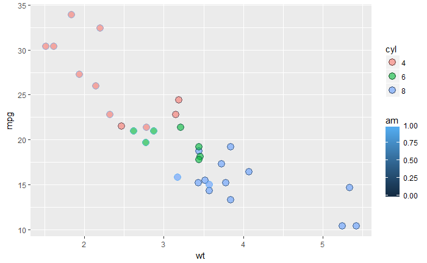

```r
# 3 - Map am to col in the above plot
ggplot(mtcars, aes(x = wt, y = mpg, fill = cyl, col = am)) +
  geom_point(shape = 21, size = 4, alpha = 0.6)
```

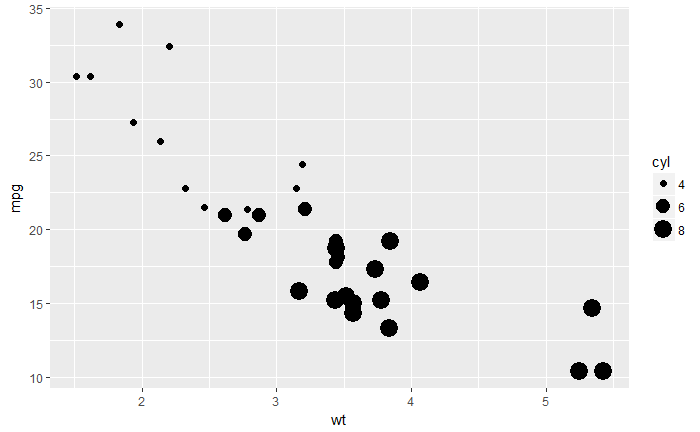

```r
# Map cyl to size
ggplot(mtcars, aes(wt,mpg,size=cyl))+ geom_point()
```

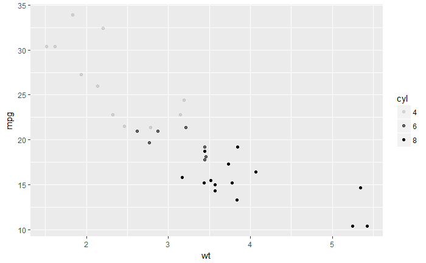

```r
# Map cyl to alpha
ggplot(mtcars, aes(wt,mpg,alpha=cyl))+ geom_point()
```

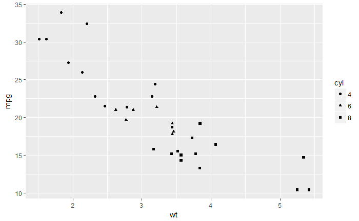

```r
# Map cyl to shape
ggplot(mtcars, aes(wt,mpg,shape=cyl))+ geom_point()
```

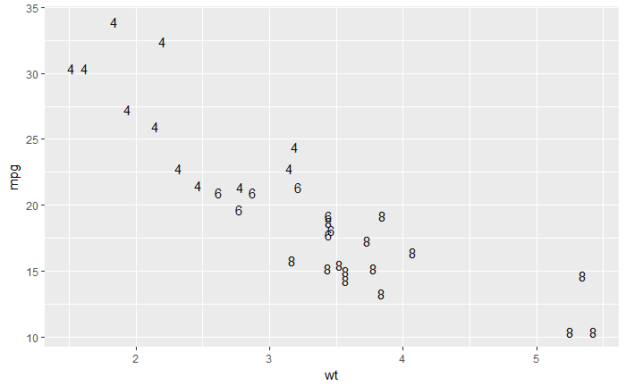

```r
# Map cyl to label
ggplot(mtcars, aes(wt,mpg,label=cyl))+geom_text()
```

Advacned geaom properties

```r
# Define a hexadecimal color
my_color <- "#4ABEFF"
# 1 - First scatter plot, with col aesthetic:
ggplot(mtcars, aes(wt, mpg, col=cyl)) + geom_point()
```

[output not shown]

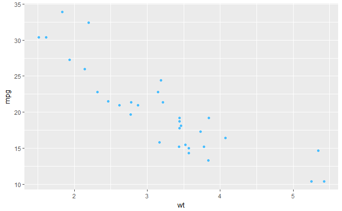

```r
# 2 - Plot 1, but set col attributes in geom layer:
ggplot(mtcars, aes(wt, mpg, col=cyl)) + geom_point(col=my_color)
```

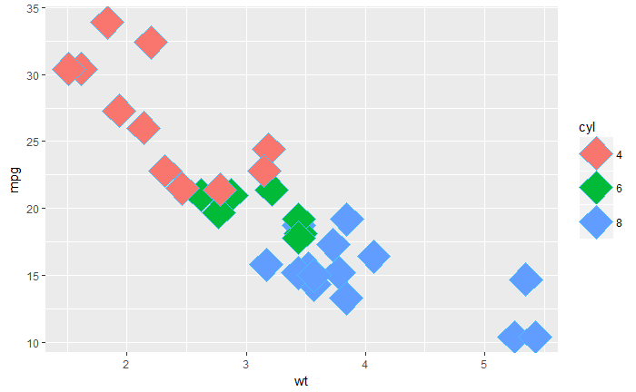

```r
# 3 - Plot 2, with fill instead of col aesthetic, plut shape and size attributes in geom layer.
ggplot(mtcars, aes(wt, mpg, fill=cyl)) + geom_point(size=10, shape= 23, col=my_color)
```

Playing with color and label

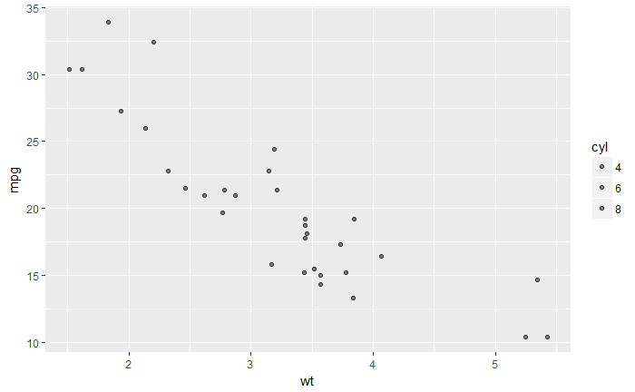

```r
# Expand to draw points with alpha 0.5
ggplot(mtcars, aes(x = wt, y = mpg, fill = cyl))+geom_point(alpha=0.5)
```

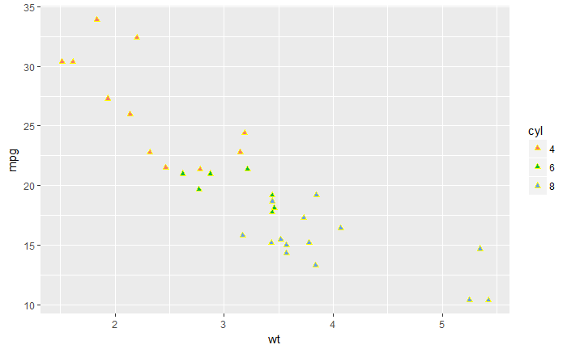

```r
# Expand to draw points with shape 24 and color yellow
ggplot(mtcars, aes(x = wt, y = mpg, fill = cyl)) + geom_point(shape=24, colour="yellow")
```

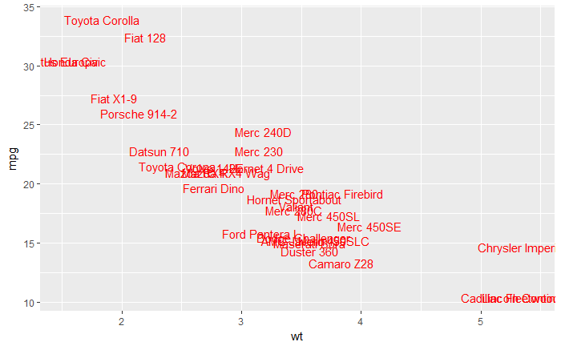

```r
# Expand to draw text with label rownames(mtcars) and color red
ggplot(mtcars, aes(x = wt, y = mpg, fill = cyl)) +
  geom_text(label = rownames(mtcars), color = 'red')
```

Advanced graphics using ggplot

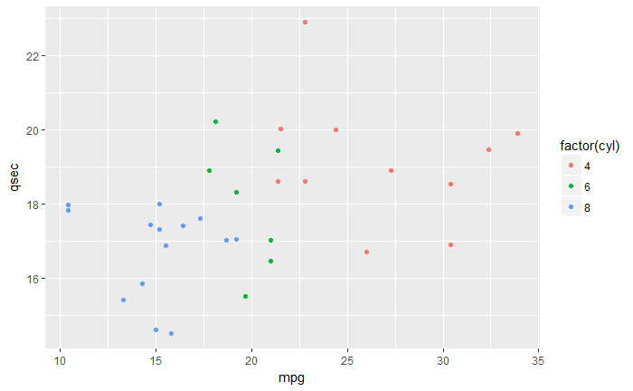

```r
# Map mpg onto x, qsec onto y and factor(cyl) onto col
ggplot(mtcars, aes(mpg, qsec, col=factor(cyl)))+geom_point()
```

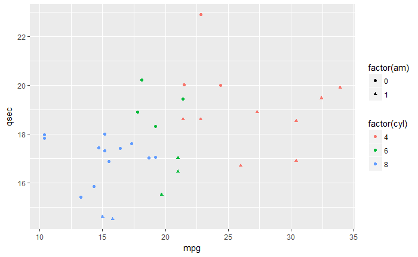

```r
# Add mapping: factor(am) onto shape
ggplot(mtcars, aes(mpg, qsec,shape=factor(am), col=factor(cyl)))+ geom_point()
```

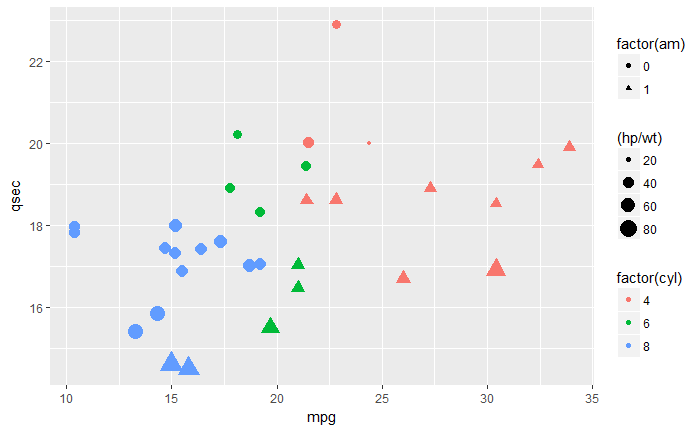

```r
# Add mapping: (hp/wt) onto size
ggplot(mtcars, aes(mpg, qsec,size=(hp/wt), shape=factor(am), col=factor(cyl)))+ geom_point()
```

Modifying aesthetics

Position - identity - value in dataframe witll pe plotted like data jittering - adding random noise to identify density position_jitter(width=0.1) scale_ - check and modify the scales of plot

scale_ args - name, limit, breaks, expand, labels labs()

```r
# The base layer, cyl.am, is available for you
cyl.am <- ggplot(mtcars, aes(x = factor(cyl), fill = factor(am)))
# Add geom (position = "stack" by default)
cyl.am +
  geom_bar()
```

[output not shown]

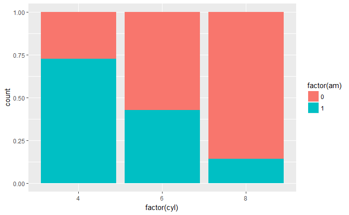

```r
# Fill - show proportion
cyl.am +
  geom_bar(position = "fill")
```

```r
# Dodging - principles of similarity and proximity
cyl.am +
  geom_bar(position ="dodge")
```

[output not shown]

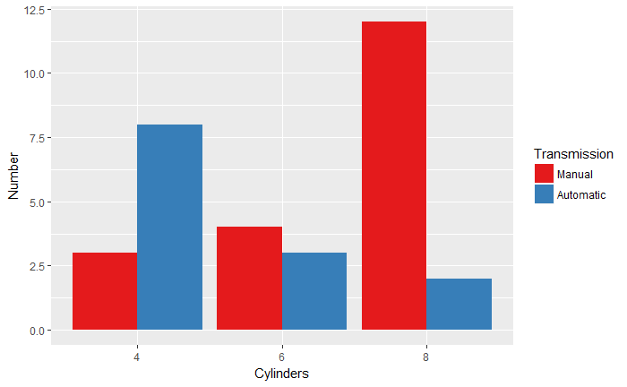

```r
# Clean up the axes with scale_ functions
val = c("#E41A1C", "#377EB8")
lab = c("Manual", "Automatic")
cyl.am +
  geom_bar(position = "dodge") +
  scale_x_discrete("Cylinders") +
  scale_y_continuous("Number") +
  scale_fill_manual("Transmission",
                    values = val,
                    labels = lab)
```

Adding scales to make the plot appropriately sized

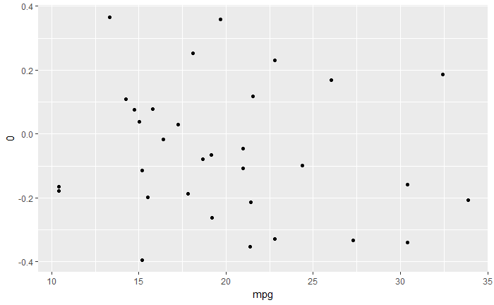

```r
# 1 - Create jittered plot of mtcars, mpg onto x, 0 onto y
ggplot(mtcars, aes(x = mpg, y = 0)) +
  geom_jitter()
```

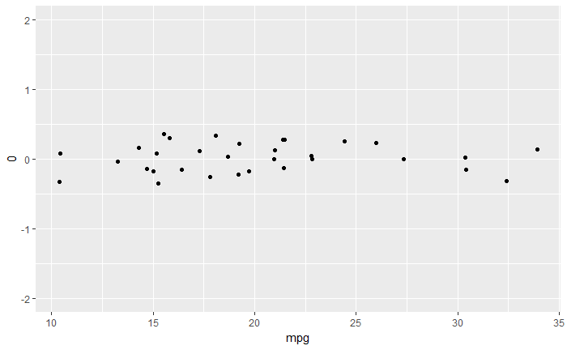

```r
# 2 - Add function to change y axis limits
ggplot(mtcars, aes(x = mpg, y = 0)) +
  geom_jitter()+
  scale_y_continuous(limits=c(-2,2))
```

Aesthetic best practices Function - important to identify audience, plot accordingly, data should be represented accurately in the plot Form - visual aesthetics

Continuous variables - scatter plots (position) color - not ideal for continuous variables size - not ideal

Aligned scales - very important(juxtaposed on same axis)

Categorical variables Color/Size - use should not lead to confusion or excess of information

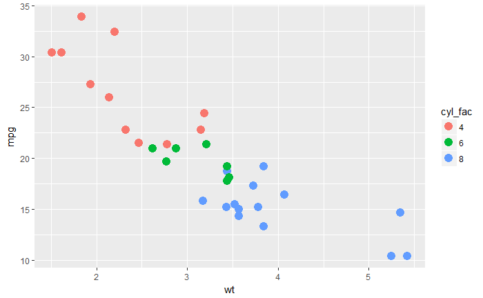

```r
# Basic scatter plot: wt on x-axis and mpg on y-axis; map cyl to col
cyl_fac<-as.factor(mtcars$cyl)
ggplot(mtcars, aes(wt, mpg, col=cyl_fac))+geom_point(size=4)
```

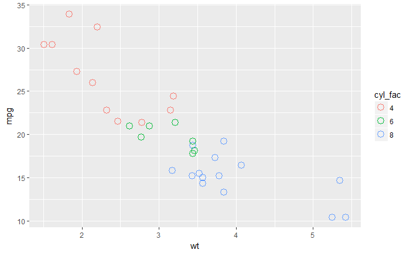

```r
# Hollow circles - an improvement
ggplot(mtcars, aes(wt, mpg, col=cyl_fac))+geom_point(shape=1, size=4)
```

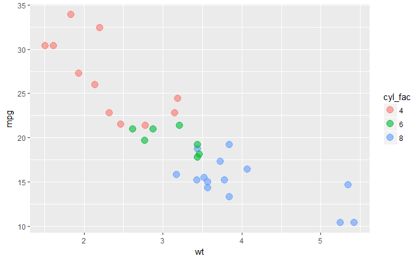

```r
# Add transparency - very nice
ggplot(mtcars, aes(wt, mpg, col=cyl_fac))+geom_point(alpha=0.6, size=4)
```

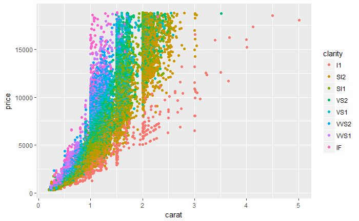

```r
# Scatter plot: carat (x), price (y), clarity (color)
ggplot(diamonds, aes(carat, price, col=clarity))+geom_point()
```

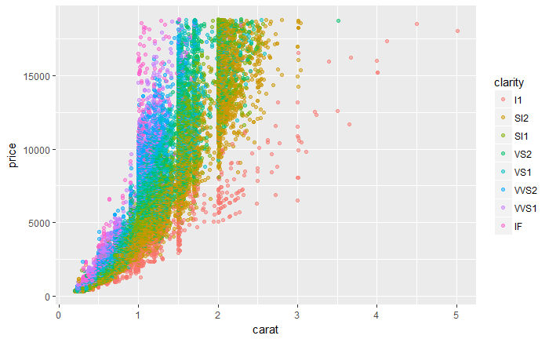

```r
# Adjust for overplotting
ggplot(diamonds, aes(carat, price, col=clarity))+geom_point(alpha=0.5)
```

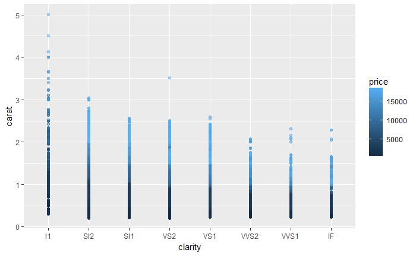

```r
# Scatter plot: clarity (x), carat (y), price (color)
ggplot(diamonds, aes(clarity, carat, col=price))+geom_point(alpha=0.5)
```

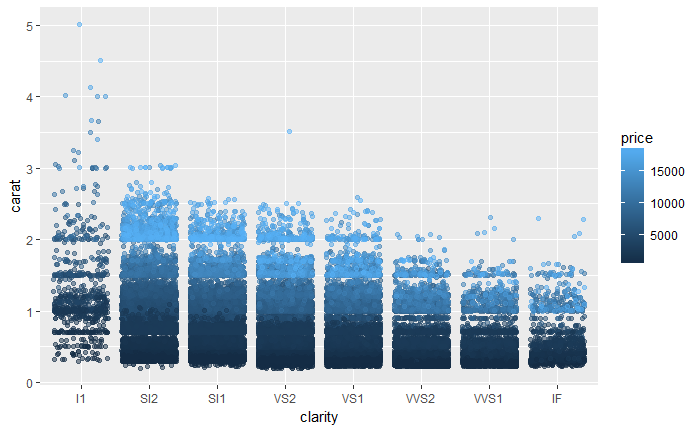

```r
# Dot plot with jittering
ggplot(diamonds, aes(clarity, carat, col=price))+geom_point(alpha=0.5, position="jitter")
```

Common plots scatter plots bar plots line plots